# Supervised Learning Classification Project: AllLife Bank Personal Loan Campaign

## Problem Statement

### Context

AllLife Bank is a US bank that has a growing customer base. The majority of these customers are liability customers (depositors) with varying sizes of deposits. The number of customers who are also borrowers (asset customers) is quite small, and the bank is interested in expanding this base rapidly to bring in more loan business and in the process, earn more through the interest on loans. In particular, the management wants to explore ways of converting its liability customers to personal loan customers (while retaining them as depositors).

A campaign that the bank ran last year for liability customers showed a healthy conversion rate of over 9% success. This has encouraged the retail marketing department to devise campaigns with better target marketing to increase the success ratio.

You as a Data scientist at AllLife bank have to build a model that will help the marketing department to identify the potential customers who have a higher probability of purchasing the loan.

### Objective

To predict whether a liability customer will buy personal loans, to understand which customer attributes are most significant in driving purchases, and identify which segment of customers to target more.

### Data Dictionary

- `ID`: Customer ID
- `Age`: Customer’s age in completed years
- `Experience`: #years of professional experience
- `Income`: Annual income of the customer (in thousand dollars)
- `ZIP Code`: Home Address ZIP code.
- `Family`: the Family size of the customer
- `CCAvg`: Average spending on credit cards per month (in thousand dollars)
- `Education`: Education Level. 1: Undergrad; 2: Graduate;3: Advanced/Professional
- `Mortgage`: Value of house mortgage if any. (in thousand dollars)
- `Personal_Loan`: Did this customer accept the personal loan offered in the last campaign? (0: No, 1: Yes)
- `Securities_Account`: Does the customer have securities account with the bank? (0: No, 1: Yes)
- `CD_Account`: Does the customer have a certificate of deposit (CD) account with the bank? (0: No, 1: Yes)
- `Online`: Do customers use internet banking facilities? (0: No, 1: Yes)
- `CreditCard`: Does the customer use a credit card issued by any other Bank (excluding All life Bank)? (0: No, 1: Yes)

## Importing necessary libraries

```python
import numpy as np
import pandas as pd
import seaborn as sns
import matplotlib.pyplot as plt
from sklearn import metrics
from sklearn.model_selection import train_test_split
from sklearn.tree import DecisionTreeClassifier
from sklearn.linear_model import LogisticRegression
from sklearn import tree
from sklearn.metrics import accuracy_score, precision_score, recall_score, f1_score, roc_auc_score, confusion_matrix
from sklearn.model_selection import GridSearchCV
```

## Loading the dataset

```python
from google.colab import drive
drive.mount('/content/drive')

df = pd.read_csv('/content/drive/MyDrive/Loan_Modelling.csv')
```

## Data Overview

- Observations
- Sanity checks

```python
df.info()
```

```
<class 'pandas.core.frame.DataFrame'>
RangeIndex: 5000 entries, 0 to 4999
Data columns (total 14 columns):
 #   Column              Non-Null Count  Dtype
---  ------              --------------  -----
 0   ID                  5000 non-null   int64
 1   Age                 5000 non-null   int64
 2   Experience          5000 non-null   int64
 3   Income              5000 non-null   int64
 4   ZIPCode             5000 non-null   int64
 5   Family              5000 non-null   int64
 6   CCAvg               5000 non-null   float64
 7   Education           5000 non-null   int64
 8   Mortgage            5000 non-null   int64
 9   Personal_Loan       5000 non-null   int64
 10  Securities_Account  5000 non-null   int64
 11  CD_Account          5000 non-null   int64
 12  Online              5000 non-null   int64
 13  CreditCard          5000 non-null   int64
dtypes: float64(1), int64(13)
memory usage: 547.0 KB
```

```python
df.describe()
```

|  | ID | Age | Experience | Income | ZIPCode | Family | CCAvg | Education | Mortgage | Personal_Loan | Securities_Account | CD_Account | Online | CreditCard |
| --- | --- | --- | --- | --- | --- | --- | --- | --- | --- | --- | --- | --- | --- | --- |
| count | 5000.000000 | 5000.000000 | 5000.000000 | 5000.000000 | 5000.000000 | 5000.000000 | 5000.000000 | 5000.000000 | 5000.000000 | 5000.000000 | 5000.000000 | 5000.00000 | 5000.000000 | 5000.000000 |
| mean | 2500.500000 | 45.338400 | 20.104600 | 73.774200 | 93169.257000 | 2.396400 | 1.937938 | 1.881000 | 56.498800 | 0.096000 | 0.104400 | 0.06040 | 0.596800 | 0.294000 |
| std | 1443.520003 | 11.463166 | 11.467954 | 46.033729 | 1759.455086 | 1.147663 | 1.747659 | 0.839869 | 101.713802 | 0.294621 | 0.305809 | 0.23825 | 0.490589 | 0.455637 |
| min | 1.000000 | 23.000000 | -3.000000 | 8.000000 | 90005.000000 | 1.000000 | 0.000000 | 1.000000 | 0.000000 | 0.000000 | 0.000000 | 0.00000 | 0.000000 | 0.000000 |
| 25% | 1250.750000 | 35.000000 | 10.000000 | 39.000000 | 91911.000000 | 1.000000 | 0.700000 | 1.000000 | 0.000000 | 0.000000 | 0.000000 | 0.00000 | 0.000000 | 0.000000 |
| 50% | 2500.500000 | 45.000000 | 20.000000 | 64.000000 | 93437.000000 | 2.000000 | 1.500000 | 2.000000 | 0.000000 | 0.000000 | 0.000000 | 0.00000 | 1.000000 | 0.000000 |
| 75% | 3750.250000 | 55.000000 | 30.000000 | 98.000000 | 94608.000000 | 3.000000 | 2.500000 | 3.000000 | 101.000000 | 0.000000 | 0.000000 | 0.00000 | 1.000000 | 1.000000 |
| max | 5000.000000 | 67.000000 | 43.000000 | 224.000000 | 96651.000000 | 4.000000 | 10.000000 | 3.000000 | 635.000000 | 1.000000 | 1.000000 | 1.00000 | 1.000000 | 1.000000 |

```python
df.head()
```

|  | ID | Age | Experience | Income | ZIPCode | Family | CCAvg | Education | Mortgage | Personal_Loan | Securities_Account | CD_Account | Online | CreditCard |
| --- | --- | --- | --- | --- | --- | --- | --- | --- | --- | --- | --- | --- | --- | --- |
| 0 | 1 | 25 | 1 | 49 | 91107 | 4 | 1.6 | 1 | 0 | 0 | 1 | 0 | 0 | 0 |
| 1 | 2 | 45 | 19 | 34 | 90089 | 3 | 1.5 | 1 | 0 | 0 | 1 | 0 | 0 | 0 |
| 2 | 3 | 39 | 15 | 11 | 94720 | 1 | 1.0 | 1 | 0 | 0 | 0 | 0 | 0 | 0 |
| 3 | 4 | 35 | 9 | 100 | 94112 | 1 | 2.7 | 2 | 0 | 0 | 0 | 0 | 0 | 0 |
| 4 | 5 | 35 | 8 | 45 | 91330 | 4 | 1.0 | 2 | 0 | 0 | 0 | 0 | 0 | 1 |

```python
df.tail()
```

|  | ID | Age | Experience | Income | ZIPCode | Family | CCAvg | Education | Mortgage | Personal_Loan | Securities_Account | CD_Account | Online | CreditCard |
| --- | --- | --- | --- | --- | --- | --- | --- | --- | --- | --- | --- | --- | --- | --- |
| 4995 | 4996 | 29 | 3 | 40 | 92697 | 1 | 1.9 | 3 | 0 | 0 | 0 | 0 | 1 | 0 |
| 4996 | 4997 | 30 | 4 | 15 | 92037 | 4 | 0.4 | 1 | 85 | 0 | 0 | 0 | 1 | 0 |
| 4997 | 4998 | 63 | 39 | 24 | 93023 | 2 | 0.3 | 3 | 0 | 0 | 0 | 0 | 0 | 0 |
| 4998 | 4999 | 65 | 40 | 49 | 90034 | 3 | 0.5 | 2 | 0 | 0 | 0 | 0 | 1 | 0 |
| 4999 | 5000 | 28 | 4 | 83 | 92612 | 3 | 0.8 | 1 | 0 | 0 | 0 | 0 | 1 | 1 |

## Exploratory Data Analysis.

- EDA is an important part of any project involving data.
- It is important to investigate and understand the data better before building a model with it.
- A few questions have been mentioned below which will help you approach the analysis in the right manner and generate insights from the data.
- A thorough analysis of the data, in addition to the questions mentioned below, should be done.

**Questions**:

1. What is the distribution of mortgage attribute? Are there any noticeable patterns or outliers in the distribution?
2. How many customers have credit cards?
3. What are the attributes that have a strong correlation with the target attribute (personal loan)?
4. How does a customer's interest in purchasing a loan vary with their age?
5. How does a customer's interest in purchasing a loan vary with their education?

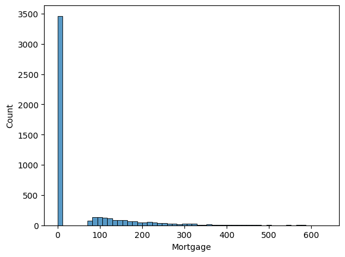

```python
sn.histplot(data = df, x = 'Mortgage');
```

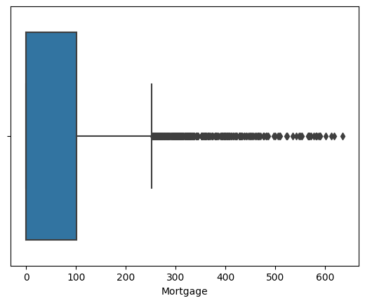

```python
sn.boxplot(data = df, x = 'Mortgage');
```

Roughly 75% of customers have 0 mortgage. The other 25% have mortgages ranging from $100k to 250k. The rest are outliers.

It's hard to say exactly how many customers have credit cards, according to the dataframe. There are only 2 columns associated with credit cards; one for monthly credit card spending and the other for credit card with another bank.

Just because a customer doesn't have any monthly spending using a credit card doesn't mean the customer doesn't have a credit card. Likewise, just because a customer doesn't have credit cards with another bank doesn't mean the customer also doesn't have a credit card with AllLife bank.

Again, there are no column indicating clearly whether or not a customer has a credit card. But I will attempt to answer the question using the available metrics.

```python
df['CCAvg'].value_counts()[0]
```

```
106
```

There are 106 customers with $0 monthly credit card spending. That means there are 4894 customers who use credit cards monthly for purchases.

```python
df['CreditCard'].value_counts()[0]
```

```
3530
```

There are 3530 customers who do not have credit cards issued by other banks. That means there are 1470 customers who do.

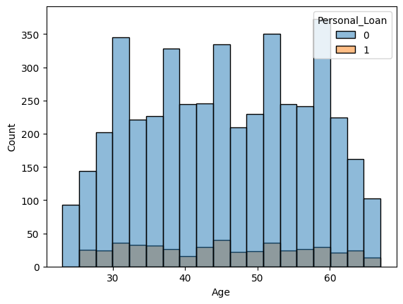

```python
sn.histplot(data=df, x='Age', hue='Personal_Loan');
```

There doesn't seem to be a correlation between a person's age and their interest in purchasing a personal loan.

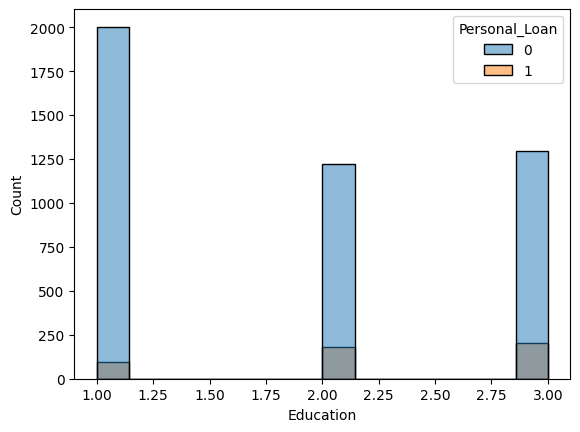

```python
sn.histplot(data=df, x='Education', hue='Personal_Loan');
```

It appears that people who are graduates or advanced/professional have higher chance of purchasing personal loans than people who are undergraduates.

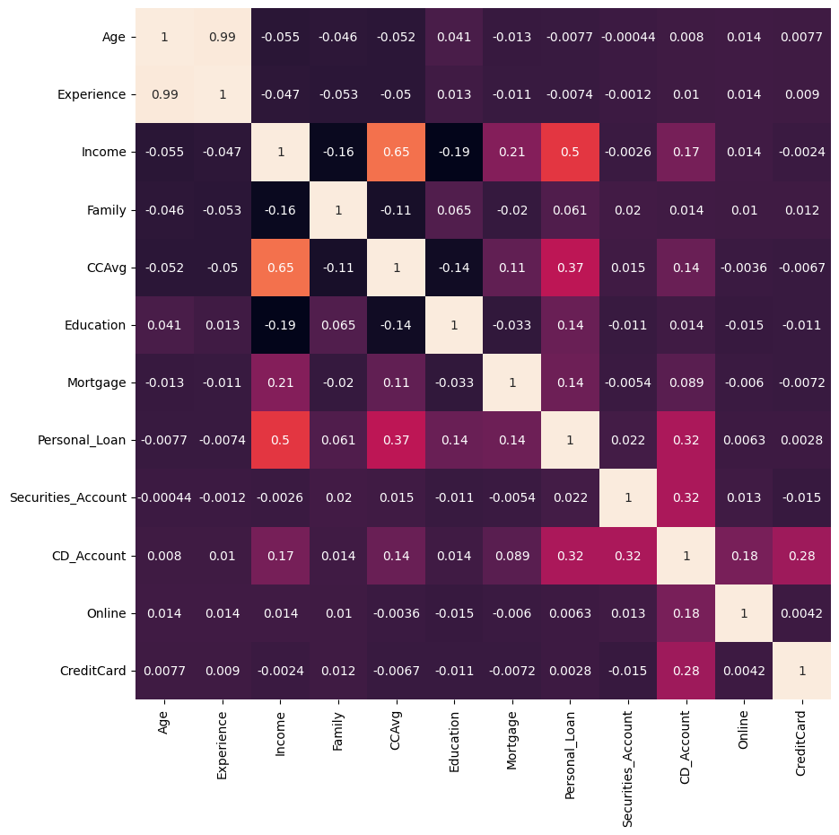

```python
plt.figure(figsize=(10, 10))
sn.heatmap(data=df[['Age', 'Experience', 'Income', 'Family', 'CCAvg', 'Education', 'Mortgage', 'Personal_Loan', 'Securities_Account', 'CD_Account', 'Online', 'CreditCard']].corr(), annot = True, cbar = False);
```

Income, CCAvg, and CD Accountt - in that order - all have correlation with personal loan.

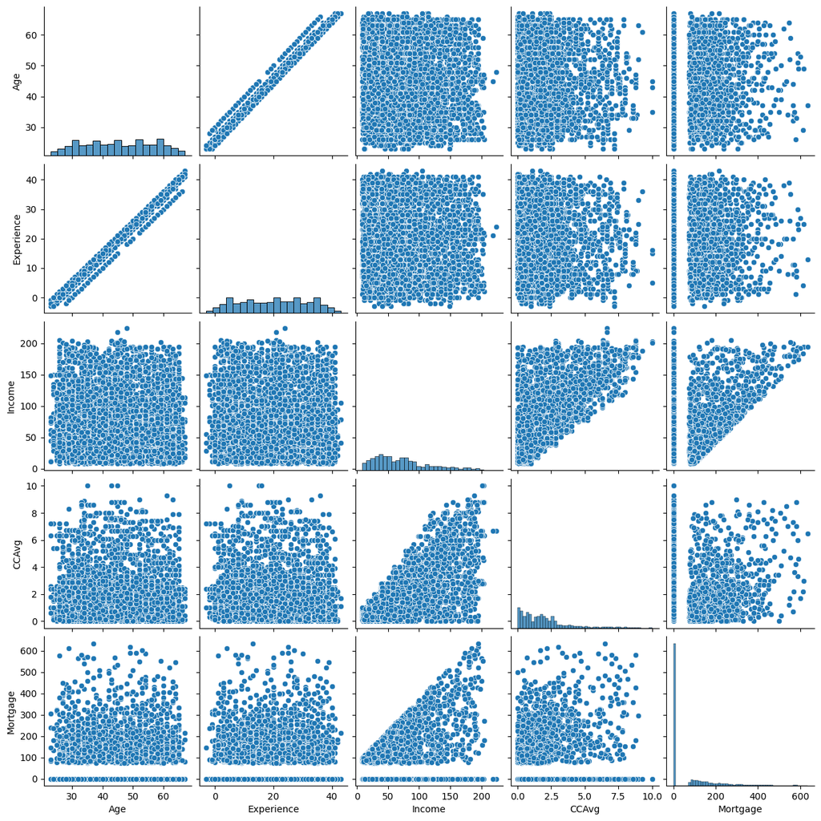

```python
sn.pairplot(data = df, vars = ['Age', 'Experience', 'Income', 'CCAvg', 'Mortgage']);
```

There's a linear relationship between a person's age and their work experience.

There's correlation between a person's income and their credit card spending as well as mortgage.

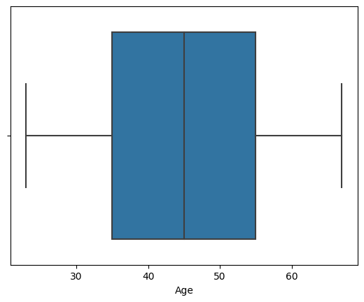

```python
sn.boxplot(data=df, x='Age');
```

The median age is 45, with 50% of customers ranging from 35 to 55 years old.

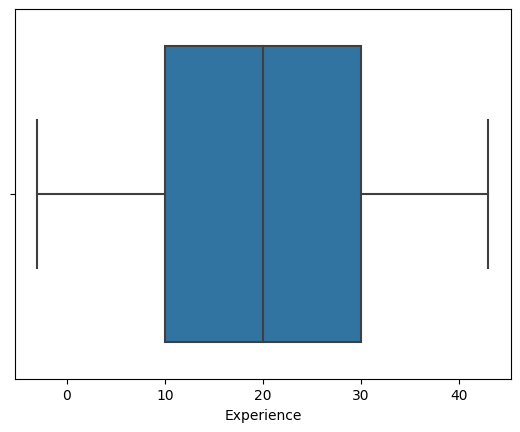

```python
sn.boxplot(data=df, x='Experience');
```

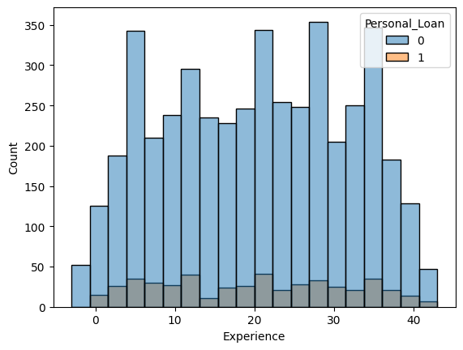

```python
sn.histplot(data=df, x='Experience', hue='Personal_Loan');
```

The median is 20 years of work experience, with 50% ranging from 10 to 30 years.

There doesn't seem to be a relationship between a person's working experience and their interest in purchasing personal loans.

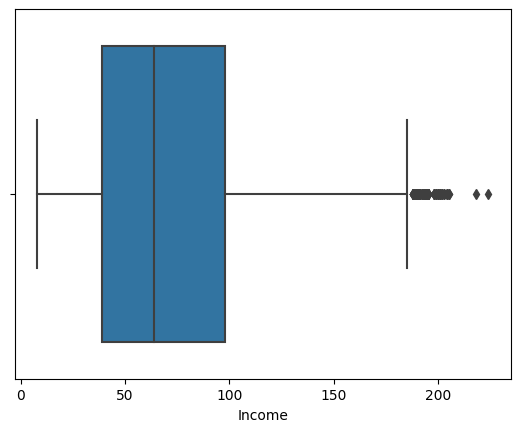

```python
sn.boxplot(data=df, x='Income');
```

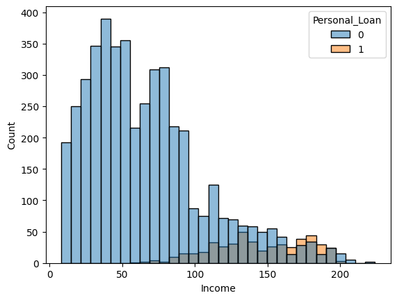

```python
sn.histplot(data=df, x='Income', hue='Personal_Loan');
```

The median income is around \$60k anually, with 50% of customers making around \$40k to \$100k annually.

People who make over \$60k are more likely to have personal loans.

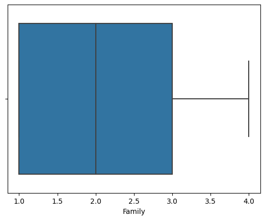

```python
sn.boxplot(data=df, x='Family');
```

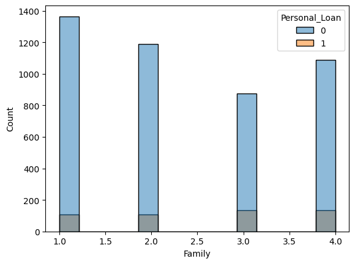

```python
sn.histplot(data=df, x='Family', hue='Personal_Loan');
```

The median family is 2 people, with 75% of families having 3 people.

Households with 3-4 people are also more likely to purchase personal loans than those with 1-2 people.

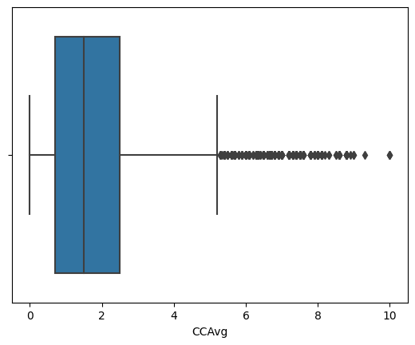

```python
sn.boxplot(data=df, x='CCAvg');
```

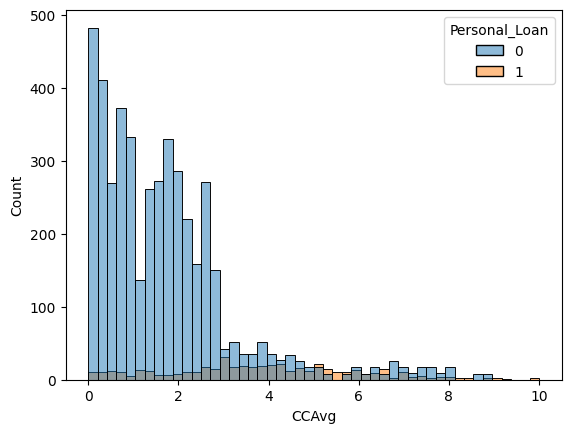

```python
sn.histplot(data=df, x='CCAvg', hue='Personal_Loan');
```

The median credit card spending is around \$1500 a month, with 50% of people spending \$800-\$2500 monthly using a credit card. There are outliers who spend \$5k-\$10k monthly with a credit card.

People who spend \$5k-\$7k monthly in credit also have higher chances of purchasing personal loans compared to others.

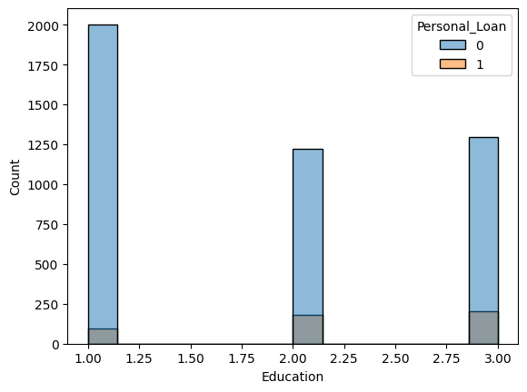

```python
sn.histplot(data=df, x='Education', hue='Personal_Loan');
```

There are more undergrads than graduates and professionals.

Graduates and professionals also have higher chances of purchasing personal loans than undergrads.

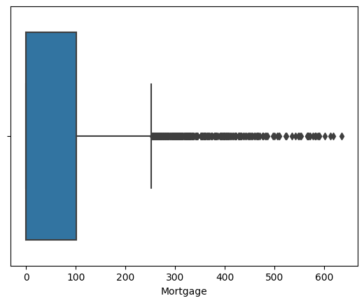

```python
sn.boxplot(data=df, x='Mortgage');
```

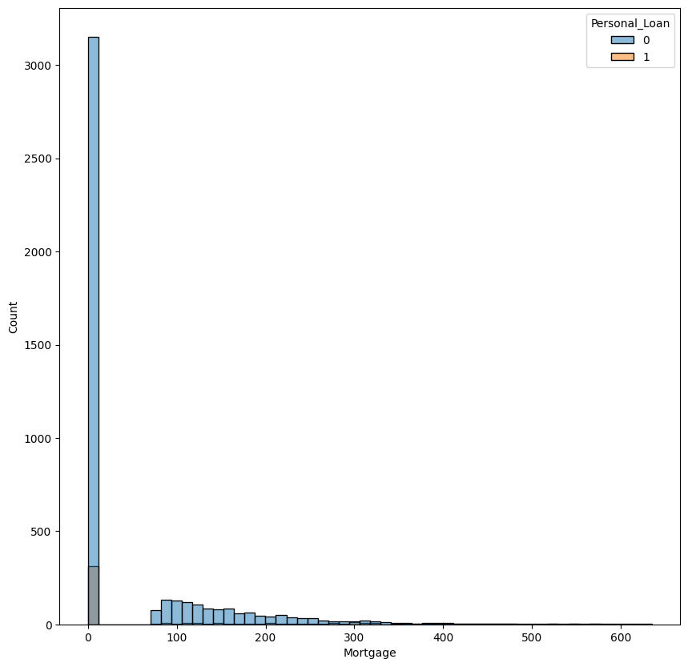

```python
plt.figure(figsize=(10,10))
sn.histplot(data=df, x='Mortgage', hue='Personal_Loan');
```

75% of people either have no mortgage or under \$100k in mortgages. There are outliers with mortgages ranging from \$250k to over \$600k.

It appears that people with around \$300k in mortgage have higher chances of purchasing personal loans.

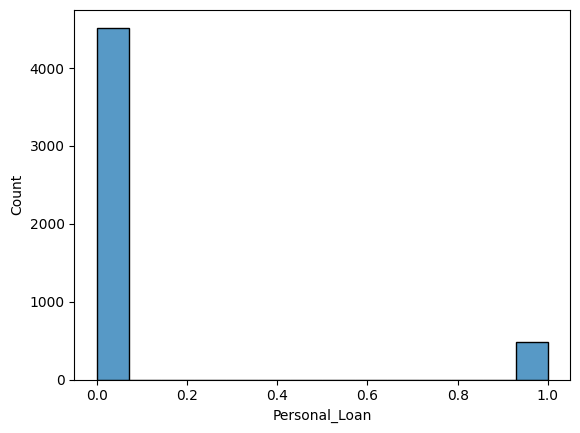

```python
sn.histplot(data=df, x='Personal_Loan');
```

The vast majority of people do not have personal loans.

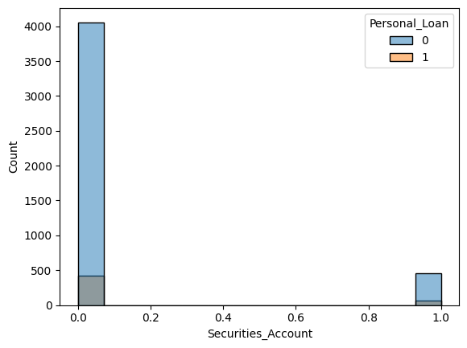

```python
sn.histplot(data=df, x='Securities_Account', hue='Personal_Loan');
```

The vast majority of people do not have securities accounts.

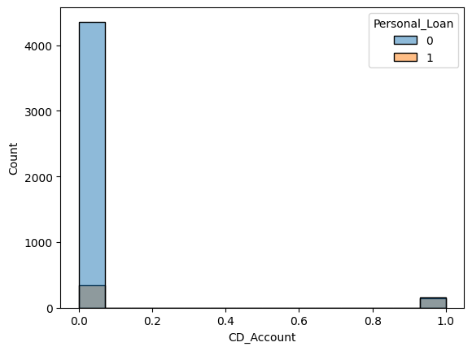

```python
sn.histplot(data=df, x='CD_Account', hue='Personal_Loan');
```

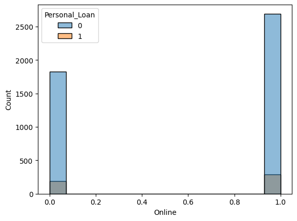

```python
sn.histplot(data=df, x='Online', hue='Personal_Loan');
```

More people use online banking than those who do not.

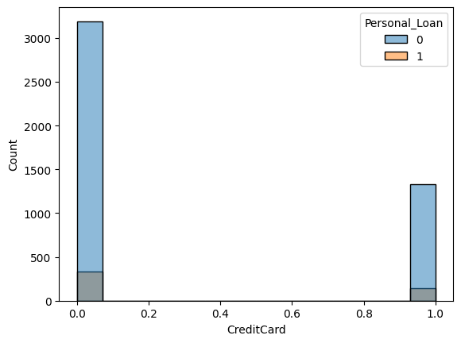

```python
sn.histplot(data=df, x='CreditCard', hue='Personal_Loan');
```

People who have no credit cards from other banks double those who do.

## Data Preprocessing

- Missing value treatment
- Feature engineering (if needed)
- Outlier detection and treatment (if needed)
- Preparing data for modeling
- Any other preprocessing steps (if needed)

There are no missing values in the dataframe. Also, there doesn't seem to be any need for feature engineering. There doesn't seem to be any major outliers that would be a cause for concern.

## Model Building

```python
X = df.drop("Personal_Loan", axis=1)
y = df["Personal_Loan"]
X_train, X_test, y_train, y_test = train_test_split(X, y, test_size=0.2, random_state=2)
```

We isolate the target variable (Personal Loans) from the feature variable (the rest of the data frame). We then split them 80/20 for training/testing, with a random seed of 2.

### Model Evaluation Criterion

- Accuracy
- Precision
- Recall
- F1 Score
- Confusion Matrix

### Model Building: Logistic Regression

```python
model = LogisticRegression()
model.fit(X_train, y_train)

y_pred_lr = model.predict(X_test)

accuracy_lr = accuracy_score(y_test, y_pred_lr)
precision_lr = precision_score(y_test, y_pred_lr)
recall_lr = recall_score(y_test, y_pred_lr)
f1_lr = f1_score(y_test, y_pred_lr)
cm_lr = confusion_matrix(y_test, y_pred_lr)

print("Accuracy:", accuracy_lr)
print("Precision:", precision_lr)
print("Recall:", recall_lr)
print("F1-score:", f1_lr)
print('Confusion Matrix:', cm_lr)
```

```
Accuracy: 0.905
Precision: 0.46296296296296297
Recall: 0.27472527472527475
F1-score: 0.3448275862068966
Confusion Matrix: [[880  29]
 [ 66  25]]
```

### Model Building: Decision Tree

```python
dTree = DecisionTreeClassifier(criterion= 'gini', random_state = 1)
dTree.fit(X_train, y_train)

y_pred_dt = dTree.predict(X_test)

accuracy_dt = accuracy_score(y_test, y_pred_dt)
precision_dt = precision_score(y_test, y_pred_dt)
recall_dt = recall_score(y_test, y_pred_dt)
f1_dt = f1_score(y_test, y_pred_dt)
cm_dt = confusion_matrix(y_test, y_pred_dt)

print("Accuracy:", accuracy_dt)
print("Precision:", precision_dt)
print("Recall:", recall_dt)
print("F1-score:", f1_dt)
print('Confusion Matrix:', cm_dt)
```

```
Accuracy: 0.981
Precision: 0.9285714285714286
Recall: 0.8571428571428571
F1-score: 0.8914285714285715
Confusion Matrix: [[903   6]
 [ 13  78]]
```

### Model Performance Improvement: Decision Tree

```python
dTree = DecisionTreeClassifier(criterion= 'gini', max_depth = 3, random_state = 2)
dTree.fit(X_train, y_train)

y_pred_dt = dTree.predict(X_test)

accuracy_dt = accuracy_score(y_test, y_pred_dt)
precision_dt = precision_score(y_test, y_pred_dt)
recall_dt = recall_score(y_test, y_pred_dt)
f1_dt = f1_score(y_test, y_pred_dt)
cm_dt = confusion_matrix(y_test, y_pred_dt)

print("Accuracy:", accuracy_dt)
print("Precision:", precision_dt)
print("Recall:", recall_dt)
print("F1-score:", f1_dt)
print('Confusion Matrix:', cm_dt)
```

```
Accuracy: 0.985
Precision: 1.0
Recall: 0.8351648351648352
F1-score: 0.9101796407185628
Confusion Matrix: [[909   0]
 [ 15  76]]
```

## Model Comparison and Final Model Selection

This is the score for logistic regression:

Accuracy: 0.905 Precision: 0.46296296296296297 Recall: 0.27472527472527475 F1-score: 0.3448275862068966 Confusion Matrix: [[880 29] [ 66 25]]

And this is the score for decision tree:

Accuracy: 0.985 Precision: 1.0 Recall: 0.8351648351648352 F1-score: 0.9101796407185628 Confusion Matrix: [[909 0] [ 15 76]]

The decision tree scores higher on all metrics. So I select decision tree.

## Actionable Insights and Business Recommendations

```python
importances = dTree.feature_importances_

for feature, importance in zip(X.columns, importances):
    print(f"{feature}: {importance}")
```

```
ID: 0.0
Age: 0.0
Experience: 0.0
Income: 0.3505375946746977
ZIPCode: 0.0
Family: 0.16161863549960206
CCAvg: 0.03313411176417145
Education: 0.4394545684382993
Mortgage: 0.0
Securities_Account: 0.0
CD_Account: 0.015255089623229558
Online: 0.0
CreditCard: 0.0
```

Based on the importances of the decision tree, I would suggest the bank to focus on selling personal loans to customers based on their education, income, family size, credit card spending, and whether or not they have a CD account.

```python
%%shell
jupyter nbconvert /content/drive/MyDrive/ColabNotebooks/SLC_Full_Code.ipynb --to html
```

```
[NbConvertApp] Converting notebook /content/drive/MyDrive/ColabNotebooks/SLC_Full_Code.ipynb to html
[NbConvertApp] Writing 2115590 bytes to /content/drive/MyDrive/ColabNotebooks/SLC_Full_Code.html
```